# act_report

### 5 Insights and a Visualization

#### Insight 1

##### Doggo dogs are the most retweeted

Some people retweet things they find insightful, entertaining and many more. A person might retweet a dog because he/she might find the dog attractive. The challenge with the dog_stage column is that a huge proportion of the dogs tweeted could not be classified. Nonetheless, working with the number of dogs which were able to be classified showed that doggo dogs were the most retweeted dogs followed closely by pupper, and then puppo and the last been floofer. The image below depicts this insight

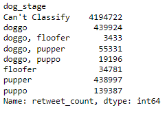

#### Insight 3

Interestingly, pupper dogs top our chart for the highly rated dog stage. Maybe people indeed love these dogs. It will be interesting to see the change that will occur if majority of dogs were to be classified. Will pupper dogs still be highly rated?

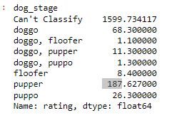

#### Insight 4

##### A doggo dog received the most retweets

A doggo received the higest number of retweets at a whooping 79515 retweets. Maybe people indeed love these dogs

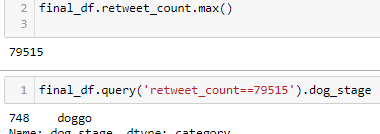

The first line of code returns the highest retweet value. The second line of code return the dog_stage with thatthe highest retweets. And there we have our confirmation A DOGGO!!!!

Insight 5

##### The numerator value of 13 was the most retweeted

With this insight we did two things. First we found an insight and then we backed our insight with somw visualization. We looked out for the rating with the highest number of retweets. We can confirm that dogs who receive a rating of 1.3 or 13/10 was the most retweeted. Below is our visualization to back this claim.

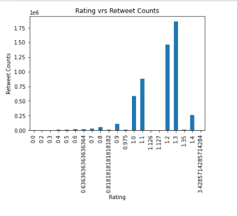